# SomaSens

Diagnosing and Handling Pre-Analytical Variation in SomaScan Proteomics

Author

Subrata Paul

## 1 Overview

SomaScan is a high-throughput aptamer-based proteomics platform capable of measuring thousands of proteins simultaneously (Candia 2025). Like other blood-based proteomic assays, SomaScan measurements can be sensitive to pre-analytical variation introduced during sample collection, processing, handling, and storage (Tatsumi et al. 2026; Candia et al. 2025). When such variation is systematic — affecting a subset of samples differently — it can produce spurious clusters in the data that are unrelated to the biological question of interest.

This resource documents a set of diagnostic and remediation strategies for identifying and handling pre-analytical variation in SomaScan data. The methods are illustrated with examples from a multi-site asthma proteomics study, but the approach generalises to any SomaScan dataset where sample quality or processing history is a concern.

The SomaLogic-provided lists of processing-sensitive proteins (fed-fasted state, freeze-thaw cycles, time to spin, time to decant, time to freeze) are central to these methods. These lists are not redistributed here; they can be obtained directly from SomaLogic. See the [`data/README.md`](https://github.com/spaul-genetics/SomaSens/blob/main/data/README.md) file for instructions on where to place them once obtained.

The examples in this resource use plasma SomaScan data from a multi-site asthma proteomics study. The samples came from several collection sites, and the unexplained split that motivated this workflow was most visible within the Denver samples. I use Denver as the main worked example because that is where the clustering problem was clearest. The methods themselves are not specific to Denver; the same diagnostic and scoring steps can be applied to other SomaScan datasets where sample handling or fasting status may have introduced systematic structure.

## 2 Diagnosing the Cause of Unexplained Sample Clusters

### 2.1 Motivation

After standard pre-processing and quality control, SomaScan data are often subjected to dimensionality reduction (e.g., PCA) and unsupervised clustering (e.g., k-means) to assess overall sample structure. In some datasets, two or more clusters emerge that cannot be attributed to the primary experimental variable (disease status, treatment arm, etc.) or to known technical factors such as assay batch or collection site.

When this occurs, a natural question is: could a pre-analytical processing difference — such as whether samples were collected from fasted or fed subjects, or experienced different freeze-thaw histories — be responsible?

### 2.2 Diagnostic Approach

SomaLogic provides, upon request, lists of proteins whose abundances are known to change substantially under specific pre-analytical conditions. For each condition, the list contains proteins along with their log2 fold change relative to a reference condition (e.g., protein abundance after 12 hours of fasting relative to the fed baseline).

The diagnostic approach works as follows:

1. **Quantify the between-group signal.** For each protein, fit a linear regression of log2 RFU on a categorical comparison variable, adjusting for relevant covariates (age, sex, disease status, ancestry PCs, assay batch). In the simplest case this is a binary contrast, but the grouping variable does not have to come from clustering. It can represent clusters, site, plate, processing group, or another experimental condition. The resulting beta coefficient for the selected contrast captures the direction and magnitude of each protein’s difference between the two groups being compared.
2. **Compare to the processing-sensitive protein lists.** For each processing condition, plot the known processing-induced log2 fold change (x-axis) against the observed between-group beta coefficient (y-axis).
3. **Interpret the concordance.** If a processing condition explains the separation between the two groups, its sensitive proteins should fall predominantly in quadrants I (both positive) and III (both negative) of this plot — meaning proteins that go up under that processing condition are also more abundant in one group, and proteins that go down are less abundant in that same group. A pattern scattered across all four quadrants indicates that condition is not the driver.

### 2.3 Example

The figure below shows this diagnostic applied to a subset of samples that formed two clusters unexplained by experimental variables. Each panel corresponds to one processing condition. The x-axis shows the known processing-induced log2 fold change provided by SomaLogic; the y-axis shows the observed cluster beta from the linear regression. Point size and colour encode statistical significance (−log₁₀ adjusted p-value). To focus on the most sensitive markers, each panel shows the five proteins with the largest positive processing effect and the five proteins with the largest negative processing effect, ranked by the x-axis fold-change column.

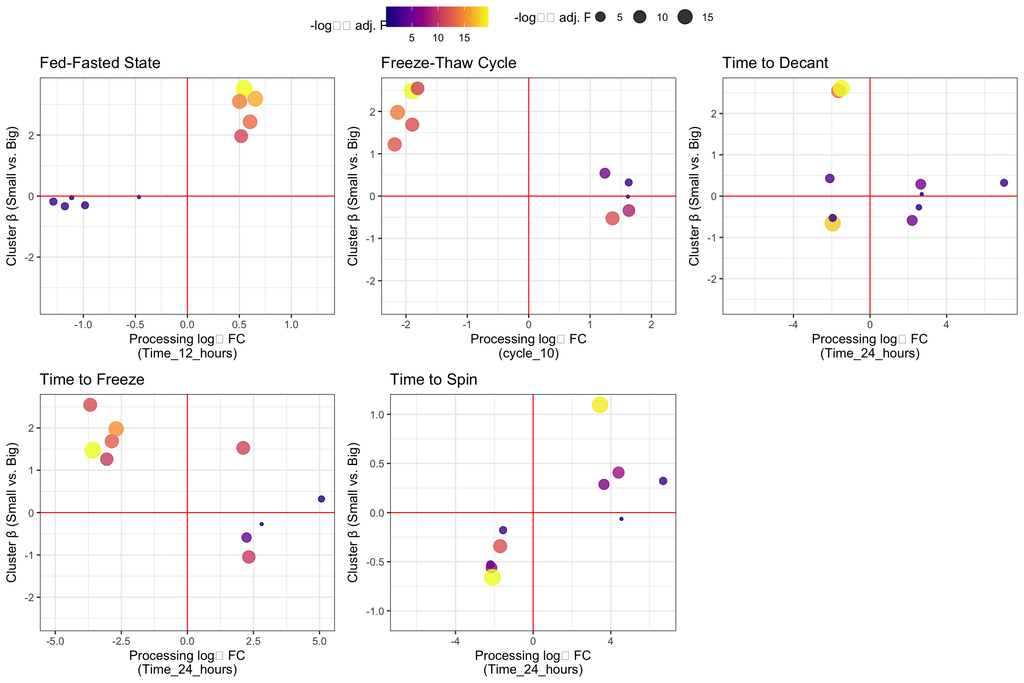

```r
# ── Data requirement ──────────────────────────────────────────────────────────
# 01_cluster_diagnosis.r needs either:
#   (a) a pre-computed cache at data/de_cluster_results.rds  (fast path), OR
#   (b) an object called `adata_meta` already in the R environment.
#
# `adata_meta` must be a log2-transformed SomaScan ADAT joined with sample
# metadata, filtered to biological samples, and augmented with a 'Cluster'
# column ('Big' / 'Small') from a prior k-means step.
#
# To use the fast path, run 01_cluster_diagnosis.r once interactively with
# adata_meta loaded; it will write data/de_cluster_results.rds automatically.
# Subsequent renders (including this page) will read that cache instead.
# ─────────────────────────────────────────────────────────────────────────────

library(here)
source(here::here("scripts/01_cluster_diagnosis.r"))
print(diag_figure)
```

### 2.4 Interpreting the Results

This pattern strongly suggests that a subset of samples were collected from subjects in a fasted state, while the remainder were collected from fed subjects, and that this biological/pre-analytical difference — rather than disease status or technical batch effects — is responsible for the clustering.

### 2.5 Data Requirements

To run this diagnostic in your own dataset you need:

- **Log2-transformed SomaScan data** with a categorical comparison variable. A cluster label (`Big` / `Small`) is one example, but clustering is not a prerequisite. The same diagnostic can be used to compare site, plate, processing group, or another experimental condition. For the plotted diagnostic, the comparison should be a defined binary contrast or a selected coefficient from a multi-level categorical variable.
- **SomaLogic processing-sensitive protein lists** (CSV format, one file per condition). These are available from SomaLogic upon request and should be placed in the `data/` directory of this repository. They are excluded from version control; see [`data/README.md`](https://github.com/spaul-genetics/SomaSens/blob/main/data/README.md).
- **Sample metadata** including any covariates to be included in the linear model (e.g., age, sex, disease status, ancestry PCs, assay batch).

The annotated R script implementing this diagnostic is available at [`scripts/01_cluster_diagnosis.r`](https://github.com/spaul-genetics/SomaSens/blob/main/scripts/01_cluster_diagnosis.r).

## 3 Fed-Fasted Score Calculation

### 3.1 Motivation

The diagnostic plot above tells us which processing condition best matches the unexplained sample clustering. In this example, the Fed-Fasted State panel showed the clearest concordance: proteins known to increase after fasting were also higher in one of the sample clusters, and proteins known to decrease after fasting were lower in that same cluster.

After seeing that pattern, the next useful step is to turn the protein-level signal into a sample-level score. The goal of the score is simple: for each sample, estimate how strongly its protein profile looks like the fasted pattern described by the SomaLogic fed-fasted experiment. This is consistent with SOMAScan work showing that nutrient state can shift serum protein profiles (Han et al. 2021).

### 3.2 Score Definition

For both scoring strategies below, I use the same weighted score. Let `R_sp` be the log2 RFU for sample `s` and protein `p`, let `mean(R_p)` be the mean log2 RFU for protein `p` across samples, and let `beta_p` be the SomaLogic fed-fasted effect size from `Time_12_hours`.

The score for sample `s` is:

$$S_s = \sum_{p \in P} (R_{sp} - \bar{R}_p) \times \beta_p$$

Here, `P` is the selected set of fed-fasted sensitive proteins. Centering each protein first makes the score depend on whether a sample is high or low for that protein relative to the dataset. Multiplying by `Time_12_hours` preserves the direction of the fasting effect. A protein that increases after fasting gets a positive weight, while a protein that decreases after fasting gets a negative weight. In this way, both types of proteins contribute in the same biological direction to the final score.

### 3.3 Strategy 1: Effect-Size Thresholding

The first strategy is to keep fed-fasted proteins with stronger SomaLogic effect sizes. Starting from the full fed-fasted CSV, we keep proteins with a non-missing `Time_12_hours` value and then apply a threshold to the absolute log2 fold change:

$$|\beta_p| \geq c$$

where `c` is the chosen effect-size cutoff. In this example, I scanned several cutoffs based on the distribution of `abs(Time_12_hours)` and compared the resulting score to the major PCA axis that captured the unexplained sample split. The score remained strong when proteins with `abs(Time_12_hours) >= 0.25` were used, while weaker-effect proteins were more likely to add noise. For that reason, `0.25` is a practical default for this example, not a universal rule.

This thresholding strategy is easy to understand and easy to reproduce. It asks only one question: which proteins have a large enough known fed-fasted effect that they should be trusted in the score?

### 3.4 Strategy 2: Independent Protein Selection

The second strategy tries to avoid giving too much influence to groups of highly correlated proteins. This is similar in spirit to clumping in PLINK. In polygenic risk score analysis, clumping keeps the strongest genetic variant in a correlated group and removes nearby variants that are in high linkage disequilibrium. The aim is to keep the strongest signal without counting the same correlated information many times (Chang et al. 2015).

Here the objects are proteins rather than genetic variants, so there is no genomic window. Instead, I rank proteins by the absolute log2 fold change in the SomaLogic `Time_12_hours` column. At each step, the protein with the largest remaining `abs(Time_12_hours)` value is kept, and proteins that are highly correlated with that selected protein are removed. The algorithm is:

1. Start with fed-fasted proteins with non-missing `Time_12_hours`.
2. From the proteins still available, select the one with the largest absolute `Time_12_hours` log2 fold change (`abs(Time_12_hours)`).
3. Remove any other available proteins that are too strongly correlated with the selected protein, using the chosen correlation threshold.
4. Repeat until no proteins remain.
5. Calculate the same weighted score using only the retained proteins.

I call the result an independent protein score. The word “independent” is practical rather than absolute: the retained proteins are not guaranteed to be statistically independent, but they are less redundant under the chosen correlation threshold.

In this example, the correlation matrix used for clumping is estimated from all sites except Denver. That choice matters. Denver is the site where the fed-fasted-like split was most visible, so including Denver when estimating protein-protein correlations can make proteins look correlated because of the very artifact we are trying to measure. Using the non-Denver samples gives a cleaner reference for deciding which proteins are redundant. In other settings, the same correlation structure could also be estimated from publicly available healthy-control SomaScan data, if the assay version and protein annotations are compatible with the study being analyzed.

### 3.5 Correlation Diagnostics

Before using the score, I like to look at the correlation structure of the selected proteins. The first plot shows the proteins retained by the simple `abs(Time_12_hours) >= 0.25` rule. The independent-protein tabs show the clumping-like selection at several correlation thresholds. In all plots, the upper triangle uses correlations calculated from all samples, while the lower triangle uses correlations calculated after excluding Denver.

**Log2 FC > 0.25**

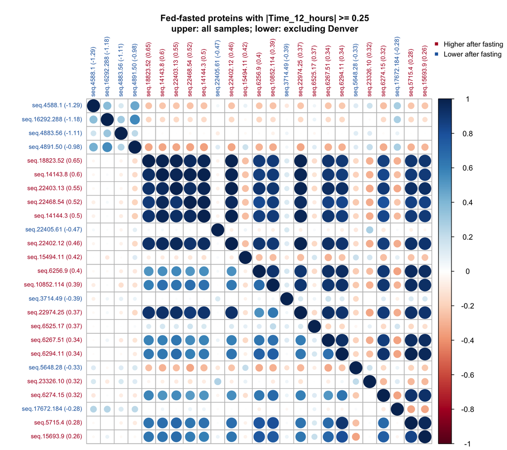

Figure 2: Correlation among fed-fasted proteins selected by absolute SomaLogic Time_12_hours log2 fold-change threshold of 0.25. The upper triangle uses all samples and the lower triangle excludes Denver. Red labels indicate proteins higher after fasting; blue labels indicate proteins lower after fasting.

**Independent: cor < 0.60**

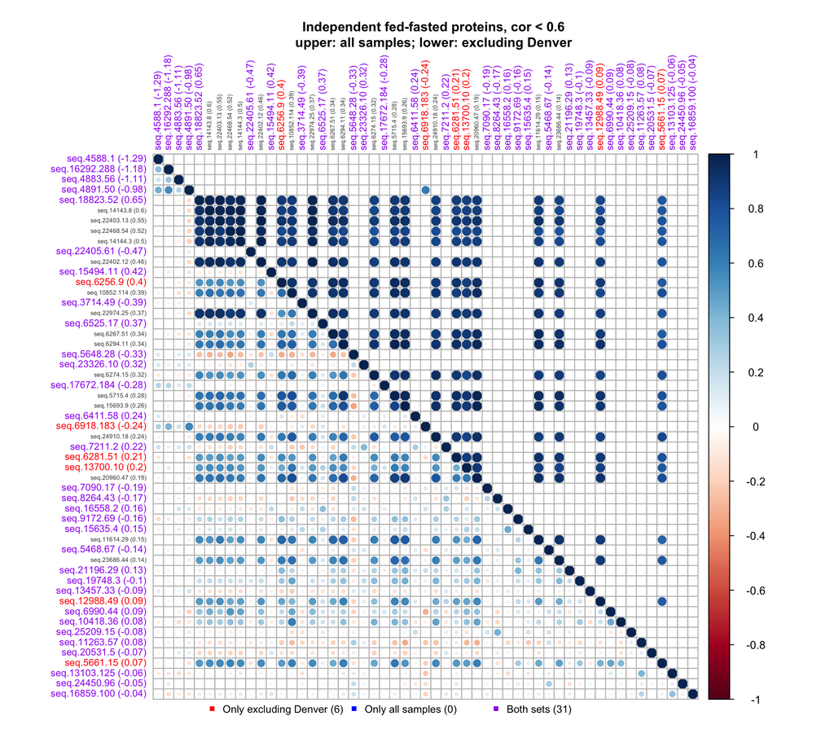

Figure 3: Color-coded correlation plot for independent fed-fasted protein selection using correlation threshold 0.60. The upper triangle uses all samples and the lower triangle excludes Denver. Red labels indicate proteins selected only when Denver is excluded, blue labels indicate proteins selected only when all samples are used, and purple labels indicate proteins selected in both cases.

**Independent: cor < 0.75**

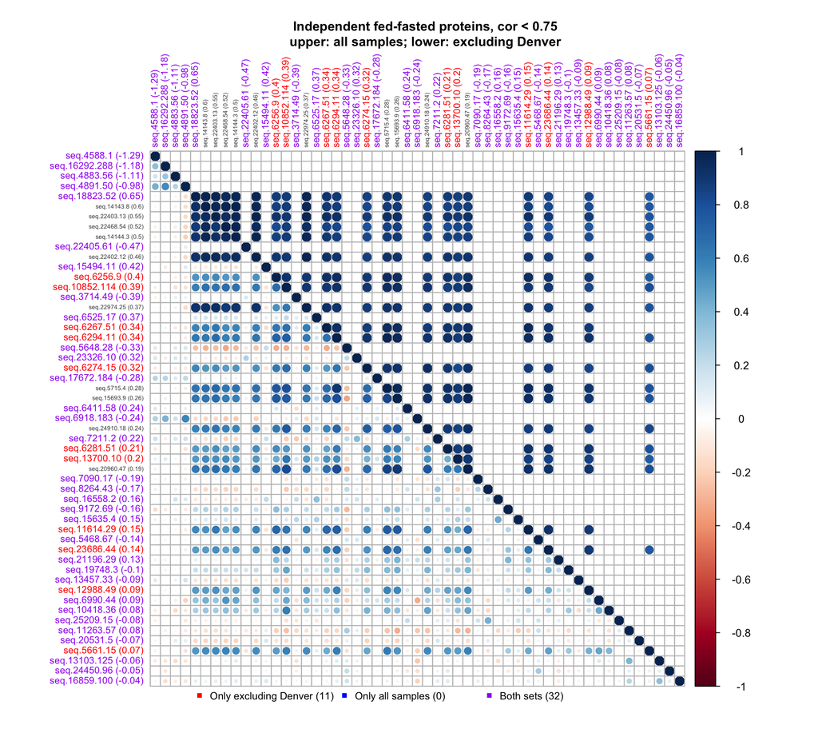

Figure 4: Color-coded correlation plot for independent fed-fasted protein selection using correlation threshold 0.75. The upper triangle uses all samples and the lower triangle excludes Denver. Red labels indicate proteins selected only when Denver is excluded, blue labels indicate proteins selected only when all samples are used, and purple labels indicate proteins selected in both cases.

**Independent: cor < 0.95**

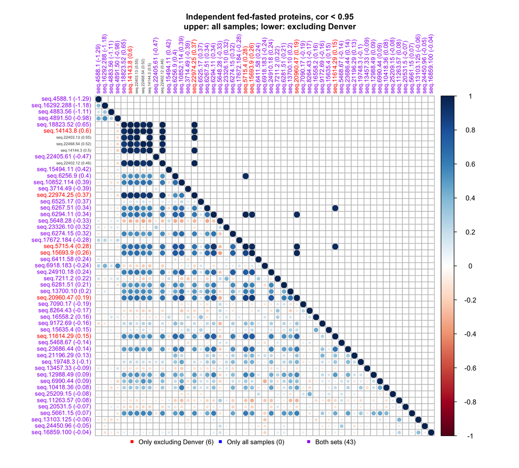

Figure 5: Color-coded correlation plot for independent fed-fasted protein selection using correlation threshold 0.95. The upper triangle uses all samples and the lower triangle excludes Denver. Red labels indicate proteins selected only when Denver is excluded, blue labels indicate proteins selected only when all samples are used, and purple labels indicate proteins selected in both cases.

### 3.6 Using The Score

Once the score is calculated, I use it as a QC summary of the fed-fasted signal. A two-component Gaussian mixture model can be fit to the score to identify samples with higher fasted-like signal versus lower fasted-like signal (Benaglia et al. 2009). Those labels can then be compared to PCA clusters, collection site, and other metadata.

The plots below show the GMM fit for each score. The histogram shows the score distribution, the black curves show the two fitted mixture components, and the colored density curves show how the existing k-means clusters are distributed along the score. The small table inside each plot summarizes how many samples from each k-means cluster fall into the lower-score and higher-score GMM groups.

**Log2 FC > 0.25**

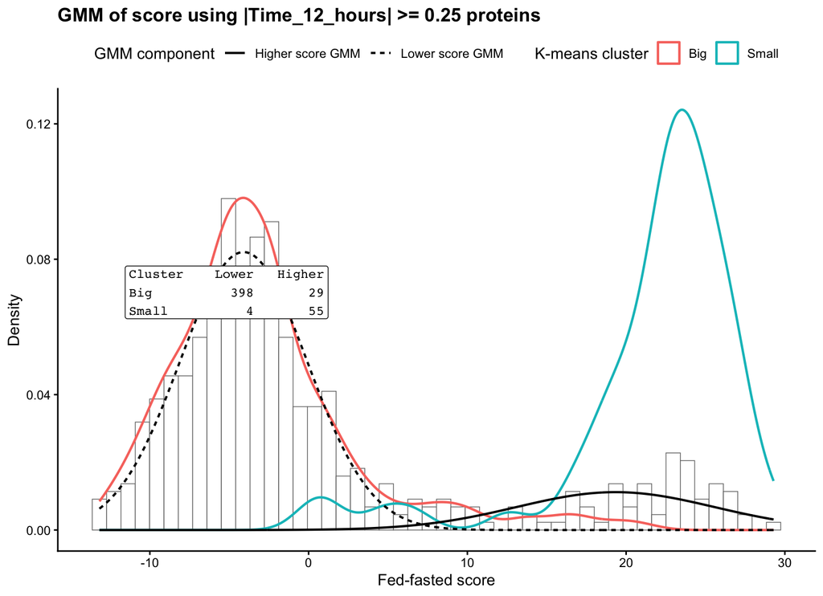

Figure 6: Gaussian mixture model fit of the fed-fasted score calculated using proteins with absolute SomaLogic Time_12_hours log2 fold change greater than or equal to 0.25.

**Independent: cor < 0.60**

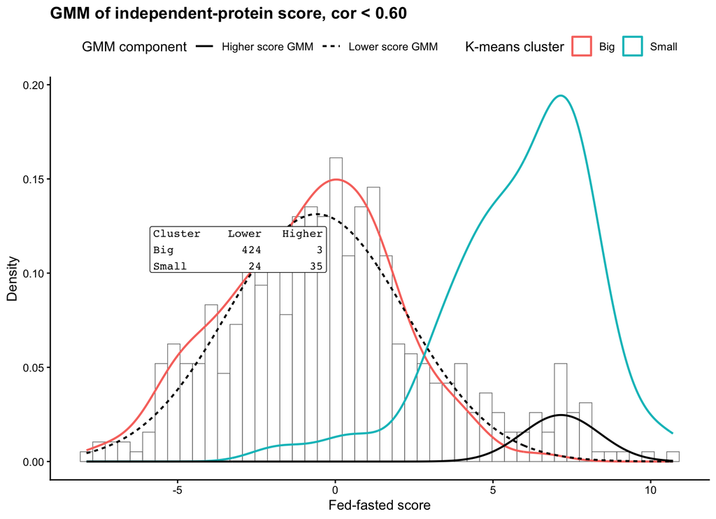

Figure 7: Gaussian mixture model fit of the fed-fasted score calculated using independent proteins selected with correlation threshold 0.60. Protein correlations used for selection were calculated after excluding Denver.

**Independent: cor < 0.75**

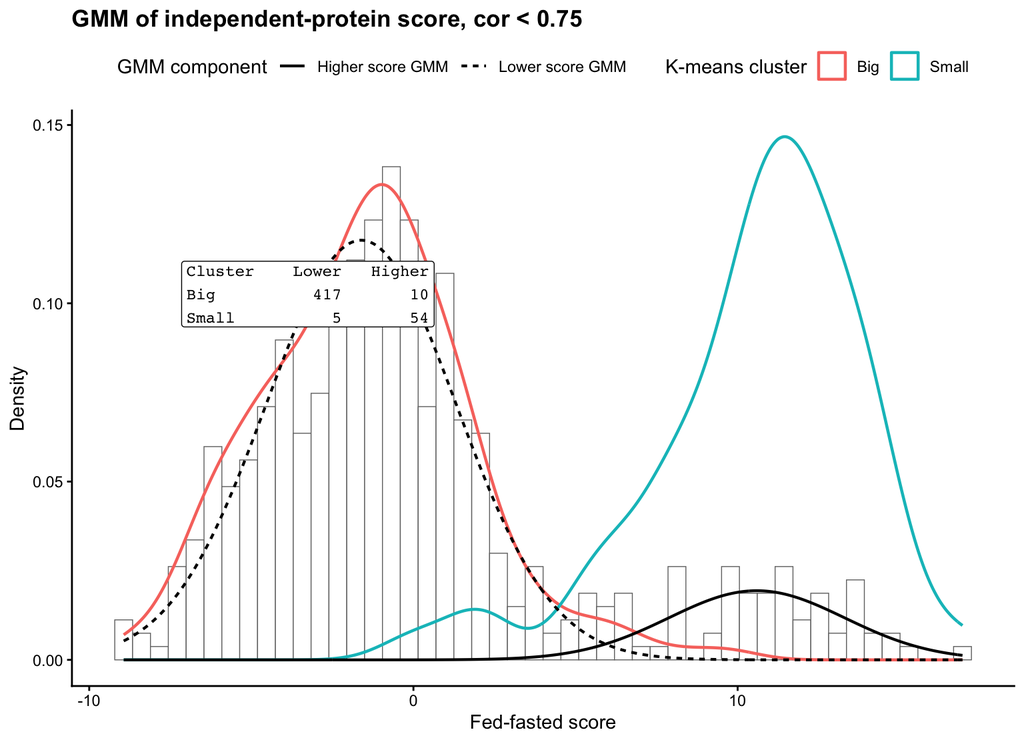

Figure 8: Gaussian mixture model fit of the fed-fasted score calculated using independent proteins selected with correlation threshold 0.75. Protein correlations used for selection were calculated after excluding Denver.

**Independent: cor < 0.95**

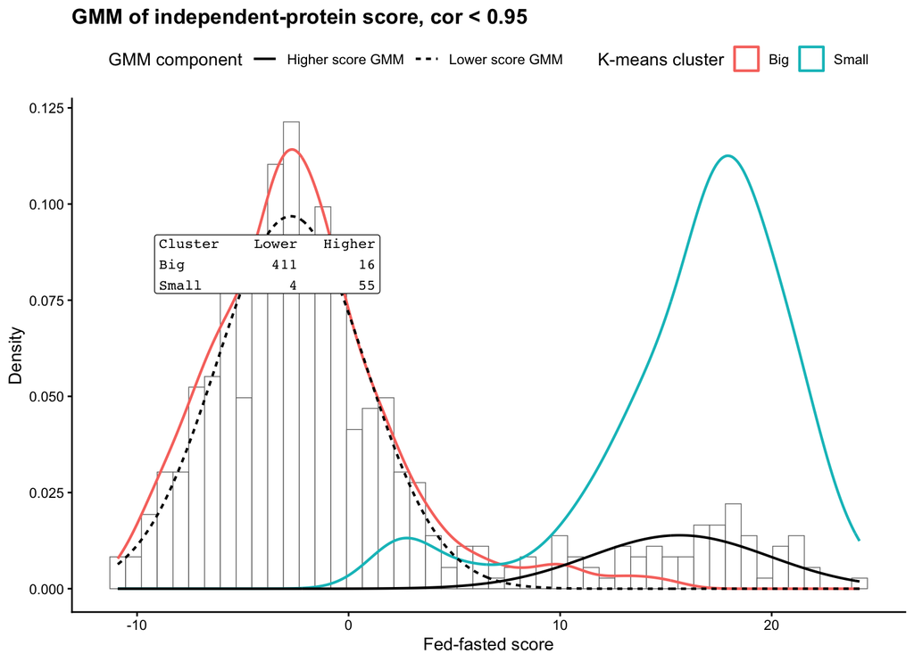

Figure 9: Gaussian mixture model fit of the fed-fasted score calculated using independent proteins selected with correlation threshold 0.95. Protein correlations used for selection were calculated after excluding Denver.

### 3.7 Sample Filtering vs. Covariate Adjustment

After identifying samples with high fed-fasted score, there are two practical ways to use this information in the downstream analysis.

The first option is sample filtering. In this approach, samples assigned to the higher fed-fasted-score GMM group are removed before differential expression analysis. This is useful when the score identifies a distinct subset of samples that appears to be affected by a pre-analytical difference rather than by the main biological question. The advantage is that we are not asking the statistical model to repair a strong handling artifact after the fact. The tradeoff is that we lose samples, and this can reduce power or change the analysis population if the removed samples are not evenly distributed across phenotypes, sites, or other study variables.

The second option is covariate adjustment. In this approach, all samples are kept, and the fed-fasted score, or sometimes the GMM class based on the score, is included as a covariate in the model. This can be attractive when the total sample size is limited, when the score varies continuously rather than forming a clear outlier group, or when filtering would remove too many samples from an important subgroup. The tradeoff is that adjustment assumes the score captures the processing effect in a way the model can handle. If the affected samples form a strong separate cluster, or if the processing signal is highly heterogeneous, a single covariate may not fully remove the artifact.

So I do not think there is one universal choice. The decision depends on the experiment, the total number of samples, how much heterogeneity is present, and how strongly the score is tangled with the biology we want to test. In this example, the score and the PCA/k-means structure pointed to a smaller group of samples with a clear fed-fasted-like signal. We found that filtering was the better option for this dataset, so the smaller high-score group was filtered out before the downstream differential expression analysis.

## 4 Differential Expression After Fed-Fasted Filtering

After filtering the smaller high-score group, the next question is how to run the differential expression analysis. The data here are already normalized SomaScan RFU values on the log2 scale, so we can use linear modeling methods directly on the protein abundance matrix.

This is where `limma` is still a reasonable baseline model (Ritchie et al. 2015). We are not using `voom` here because `voom` was designed mainly for RNA-seq-style count data, where the mean-variance relationship is tied to count sampling and negative binomial-like behavior (Law et al. 2014). SomaScan RFU values are not read counts. After the SomaScan normalization steps and log2 transformation, the working data are continuous protein abundance measurements, so the ordinary limma linear model with empirical Bayes variance moderation is appropriate as a fixed-effect baseline.

The cleaned model helpers are in [`scripts/03_de_analysis.r`](https://github.com/spaul-genetics/SomaSens/blob/main/scripts/03_de_analysis.r). That script was organized from the older development scripts and contains:

- `fit_limma_model()` for the fixed-effect limma analysis without `voom`.
- `fit_dream_model()` for the mixed-effect Dream analysis with site as a random effect.
- `fit_lmer_test_model()` for a per-protein `lmerTest` comparison model.
- `fit_lmer_seq_model()` as an optional placeholder for an `lmerSeq` comparison model.
- `run_dream_all_samples()` and `run_dream_indep075_filter()` for the worked comparison used below.
- `volcano_break_axis()`, `plot_all_samples_dream_volcano()`, and `plot_indep075_dream_volcano()` for the volcano plots.

The important pattern from testing these approaches was that modeling site as a random effect improved the signal compared with the fixed-effect limma baseline. Among the random-effect approaches, Dream was the most useful for this workflow because it combines linear mixed models with limma-style empirical Bayes moderation (Hoffman and Roussos 2021).

We also used split eBayes in the Dream framework. SomaScan proteins are measured in different dilution groups, and the technical variance structure is not necessarily the same across those groups. Applying empirical Bayes moderation separately within each dilution group lets the variance borrowing happen within a more comparable set of measurements. In our analysis, this split eBayes Dream model was more powerful than the alternatives we tested.

The point of the all-sample plot is not that it produces many significant proteins. It is the baseline comparison showing that, before filtering, the asthma differential-expression signal is relatively muted. Using the same display threshold shown in the volcano plots, 23 proteins are highlighted in the all-sample model, compared with 70 proteins after fed-fasted filtering. After filtering, many more biologically meaningful proteins become visible, which is why sample filtering was useful in this dataset.

IgE is an outlying signal in both dimensions: it has a very large log2 fold change on the x-axis and a very large `-log10` adjusted p-value on the y-axis. In a usual single-scale volcano plot, this stretches the axes so much that the remaining proteins are compressed into a small part of the figure. For that reason, we used a customized volcano plot with broken/faceted axes so that the IgE result remains visible while the rest of the differential-expression pattern can still be inspected.

**After Fed-Fasted Filtering**

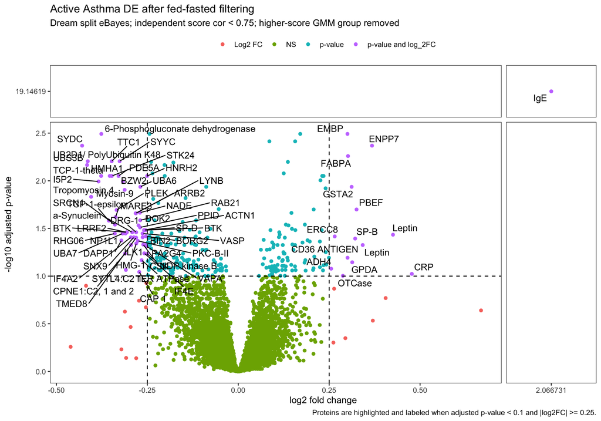

Figure 10: Volcano plot for Active Asthma differential expression after filtering the higher-score GMM group identified from the independent fed-fasted score at correlation threshold 0.75. The model is Dream with site as a random effect and split empirical Bayes moderation by SomaScan dilution group. After filtering, more highlighted and biologically interpretable proteins become visible. Customized axis breaks are used because the IgE log2 fold change and adjusted significance are much larger than the rest of the proteins.

**All Samples**

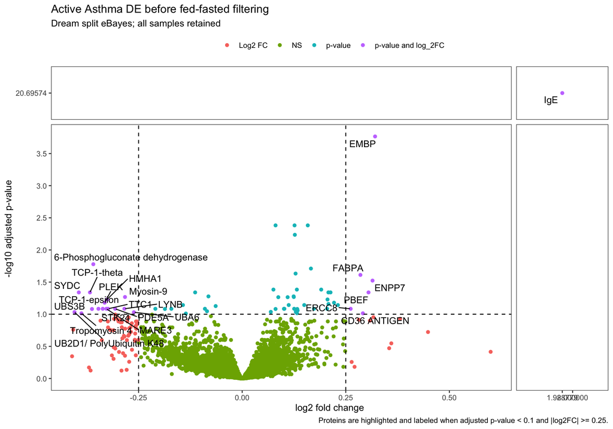

Figure 11: Volcano plot for Active Asthma differential expression using all samples. The model is Dream with site as a random effect and split empirical Bayes moderation by SomaScan dilution group. This panel is included as the baseline comparison before fed-fasted filtering; the broader asthma signal is relatively muted when all samples are retained. Customized axis breaks are used because the IgE log2 fold change and adjusted significance are much larger than the rest of the proteins.

## References

Benaglia, Tatiana, Didier Chauveau, David R. Hunter, and Derek Young. 2009. “mixtools: An R Package for Analyzing Finite Mixture Models.” *Journal of Statistical Software* 32 (6): 1–29. https://www.jstatsoft.org/v32/i06/.

Candia, Julian. 2025. “SomaScan Bioinformatics: Normalization, Quality Control, and Assessment of Pre-Analytical Variation.” *Methods in Molecular Biology* 2929: 107–27. https://doi.org/10.1007/978-1-0716-4595-6_9.

Candia, Julian, Giovanna Fantoni, Ruin Moaddel, Francheska Delgado-Peraza, Nader Shehadeh, Toshiko Tanaka, and Luigi Ferrucci. 2025. “Effects of in Vitro Hemolysis and Repeated Freeze-Thaw Cycles in Protein Abundance Quantification Using the SomaScan and Olink Assays.” *Journal of Proteome Research* 24 (5): 2517–28. https://doi.org/10.1021/acs.jproteome.5c00069.

Chang, Christopher C., Carson C. Chow, Laurent C. A. M. Tellier, Shashaank Vattikuti, Shaun M. Purcell, and James J. Lee. 2015. “Second-Generation PLINK: Rising to the Challenge of Larger and Richer Datasets.” *GigaScience* 4 (1). https://doi.org/10.1186/s13742-015-0047-8.

Han, Kim, Komudi Singh, Matthew J. Rodman, Shahin Hassanzadeh, Yvonne Baumer, Rebecca D. Huffstutler, Jinguo Chen, et al. 2021. “Identification and Validation of Nutrient State-Dependent Serum Protein Mediators of Human CD4+ t Cell Responsiveness.” *Nutrients* 13 (5): 1492. https://doi.org/10.3390/nu13051492.

Hoffman, Gabriel E., and Panos Roussos. 2021. “dream: Powerful Differential Expression Analysis for Repeated Measures Designs.” *Bioinformatics* 37 (2): 192–201. https://doi.org/10.1093/bioinformatics/btaa687.

Law, Charity W., Yunshun Chen, Wei Shi, and Gordon K. Smyth. 2014. “voom: Precision Weights Unlock Linear Model Analysis Tools for RNA-Seq Read Counts.” *Genome Biology* 15 (2): R29. https://doi.org/10.1186/gb-2014-15-2-r29.

Ritchie, Matthew E., Belinda Phipson, Di Wu, Yifang Hu, Charity W. Law, Wei Shi, and Gordon K. Smyth. 2015. “limma Powers Differential Expression Analyses for RNA-Sequencing and Microarray Studies.” *Nucleic Acids Research* 43 (7): e47. https://doi.org/10.1093/nar/gkv007.

Tatsumi, Megumi, Tomoko Miyakawa, Takako Enokida, Haruna Kaneko, Kosuke Saito, Shinsuke Hidese, Yuji Takahashi, Yuichi Goto, Hiroshi Kunugi, and Kotaro Hattori. 2026. “The Effect of Preanalytical Factors on Cerebrospinal Fluid and Plasma Proteomics: A Systematic Experimental Study.” *Clinical Proteomics*. https://doi.org/10.1186/s12014-026-09604-5.